# PRA2: Limpieza y análisis de datos

Álvaro López y Jorge Sainero

30 de mayo de 2022

```r
if (!require('ggplot2')) install.packages('ggplot2'); library('ggplot2')
```

# 1 Descripción del dataset

El dataset que hemos elegido para realizar esta práctica es el que aperecía como una de las posibles opciones del enunciado [“Titanic: Machine Learning from Disaster”](https://www.kaggle.com/c/titanic).

Este dataset contiene información sobre los pasajeros que iban en el Titanic y es un conjunto de datos importante y relevante a nivel histórico porque contiene información sobre el naufragio que es una de las mayores tragedias marítimas de la historia.

Este dataset además pretende responder a qué criterios se siguieron a la hora de salvar las vidas de los pasajeros y la tripulación o si simplemente fue azar.

# 2 Selección de los datos de interés

Comenzamos cargando el dataset y viendo la estructura de este.

```r
titanic <- read.csv('data/titanic_train_data.csv')
str(titanic)
```

```
## 'data.frame':    891 obs. of  12 variables:
##  $ PassengerId: int  1 2 3 4 5 6 7 8 9 10 ...
##  $ Survived   : int  0 1 1 1 0 0 0 0 1 1 ...
##  $ Pclass     : int  3 1 3 1 3 3 1 3 3 2 ...
##  $ Name       : chr  "Braund, Mr. Owen Harris" "Cumings, Mrs. John Bradley (Florence Briggs Thayer)" "Heikkinen, Miss. Laina" "Futrelle, Mrs. Jacques Heath (Lily May Peel)" ...
##  $ Sex        : chr  "male" "female" "female" "female" ...
##  $ Age        : num  22 38 26 35 35 NA 54 2 27 14 ...
##  $ SibSp      : int  1 1 0 1 0 0 0 3 0 1 ...
##  $ Parch      : int  0 0 0 0 0 0 0 1 2 0 ...
##  $ Ticket     : chr  "A/5 21171" "PC 17599" "STON/O2. 3101282" "113803" ...
##  $ Fare       : num  7.25 71.28 7.92 53.1 8.05 ...
##  $ Cabin      : chr  "" "C85" "" "C123" ...
##  $ Embarked   : chr  "S" "C" "S" "S" ...
```

Observamos que el dataset tiene 891 observaciones donde cada observación representa a un pasajero y hay 12 columnas que informan cada registro.

Las columnas son las siguientes:

| Columna | Descripción |
| --- | --- |
| PassengerId | Id para identificar el registro. Único para cada fila |
| Survived | Indica si el pasajero sobrevivió o no. 0 = No, 1 = Sí |
| Pclass | Clase del billete. 1 = primera, 2 = segunda, 3 = tercera |
| Name | Nombre del pasajaro |
| Sex | Género del pasajero |
| Age | Edad del pasajero |
| SibSp | Número de hermanos y pareja del pasajero que viajaban en el barco |
| Parch | Número de padres e hijos del pasajero que viajaban en el barco |
| Ticket | Número del ticket |
| Fare | Precio del ticket |
| Cabin | Número de la cabina |
| Embarked | Indica donde embarcó el pasajero. C = Cherbourg, Q = Queenstown, S = Southampton |

## 2.1 Eliminación de las columnas que no son de interés

De estas colunmas a priori el PassengerId y el Nombre no nos aportan niguna información así que las eliminaremos.

```r
titanic <- titanic[,c(2,3,5:12)]
```

Revisamos el resto de los campos para ver si hay alguno más que no vaya a aportar valor al análisis.

```r
head(titanic, 10)
```

```
##    Survived Pclass    Sex Age SibSp Parch           Ticket    Fare Cabin
## 1         0      3   male  22     1     0        A/5 21171  7.2500
## 2         1      1 female  38     1     0         PC 17599 71.2833   C85
## 3         1      3 female  26     0     0 STON/O2. 3101282  7.9250
## 4         1      1 female  35     1     0           113803 53.1000  C123
## 5         0      3   male  35     0     0           373450  8.0500
## 6         0      3   male  NA     0     0           330877  8.4583
## 7         0      1   male  54     0     0            17463 51.8625   E46
## 8         0      3   male   2     3     1           349909 21.0750
## 9         1      3 female  27     0     2           347742 11.1333
## 10        1      2 female  14     1     0           237736 30.0708
##    Embarked
## 1         S
## 2         C
## 3         S
## 4         S
## 5         S
## 6         Q
## 7         S
## 8         S
## 9         S
## 10        C
```

Observando los campos Ticket y Cabin parece que van a ser identificadores únicos o casi únicos y que no van a aportar valor al análisis así que decidimos eliminarlos también.

```r
titanic <- titanic[,c(1:6,8,10)]
```

## 2.2 Cambio de tipo de las columnas

```r
titanic$Survived <- factor(titanic$Survived, levels = c(0,1), labels = c('No','Yes'))
titanic$Pclass <- factor(titanic$Pclass, levels = c(1,2,3), labels = c('1st','2nd','3rd'))
titanic$Sex <- as.factor(titanic$Sex)
titanic$Embarked <- factor(titanic$Embarked, levels = c('C','Q','S'), labels = c('Cherbourg','Queenstown','Southampton'))
```

Comprobamos que este cambio se ha realizado correctamente.

```r
summary(titanic)
```

```
##  Survived  Pclass        Sex           Age            SibSp
##  No :549   1st:216   female:314   Min.   : 0.42   Min.   :0.000
##  Yes:342   2nd:184   male  :577   1st Qu.:20.12   1st Qu.:0.000
##            3rd:491                Median :28.00   Median :0.000
##                                   Mean   :29.70   Mean   :0.523
##                                   3rd Qu.:38.00   3rd Qu.:1.000
##                                   Max.   :80.00   Max.   :8.000
##                                   NA's   :177
##      Parch             Fare               Embarked
##  Min.   :0.0000   Min.   :  0.00   Cherbourg  :168
##  1st Qu.:0.0000   1st Qu.:  7.91   Queenstown : 77
##  Median :0.0000   Median : 14.45   Southampton:644
##  Mean   :0.3816   Mean   : 32.20   NA's       :  2
##  3rd Qu.:0.0000   3rd Qu.: 31.00
##  Max.   :6.0000   Max.   :512.33
##
```

# 3 Limpieza de datos

## 3.1 Análisis de nulos, ceros y elementos vacíos

```r
colSums(is.na(titanic))
```

```
## Survived   Pclass      Sex      Age    SibSp    Parch     Fare Embarked
##        0        0        0      177        0        0        0        2
```

Vemos que tenemos 2 registros con la variable *Embarked* a nulo. Esto no nos debería preocupar demasiado ya que no son demasiados y podríamos tomar la decisión de eliminar estos registros del dataset. En cambio tenemos 177 registros con la variable *Age* a nulo. En este caso si tenemos que decidir entre imputar los valores o eliminar la variable del análisis porque no es factible eliminar casi el 20% de los registros del conjunto.

```r
colSums(titanic=="")
```

```
## Survived   Pclass      Sex      Age    SibSp    Parch     Fare Embarked
##        0        0        0       NA        0        0        0       NA
```

```r
colSums(titanic==0)
```

```
## Survived   Pclass      Sex      Age    SibSp    Parch     Fare Embarked
##        0        0        0       NA      608      678       15       NA
```

Comprobando también que valores son vacíos o cero no vemos nada extraño. Observamos que hay un gran número de personas que viajan sin familiares o sin familia (*SibSp* y *Parch* igual a 0) y que hay 15 pasajeros que viajan gratis (*Fare* igual a 0).

### 3.1.1 Tratamiento de valores nulos

Como hemos comentado antes, en el caso de los registros con las variable *Embarked* a nula los vamos a eliminar.

```r
ind.Embarked <- which(is.na(titanic$Embarked))
titanic <- titanic[-ind.Embarked,]
```

La opción por la que hemos optado para tratar este caso es calcular el valor de la variable *Age* para los registros que tienen valor nulo.

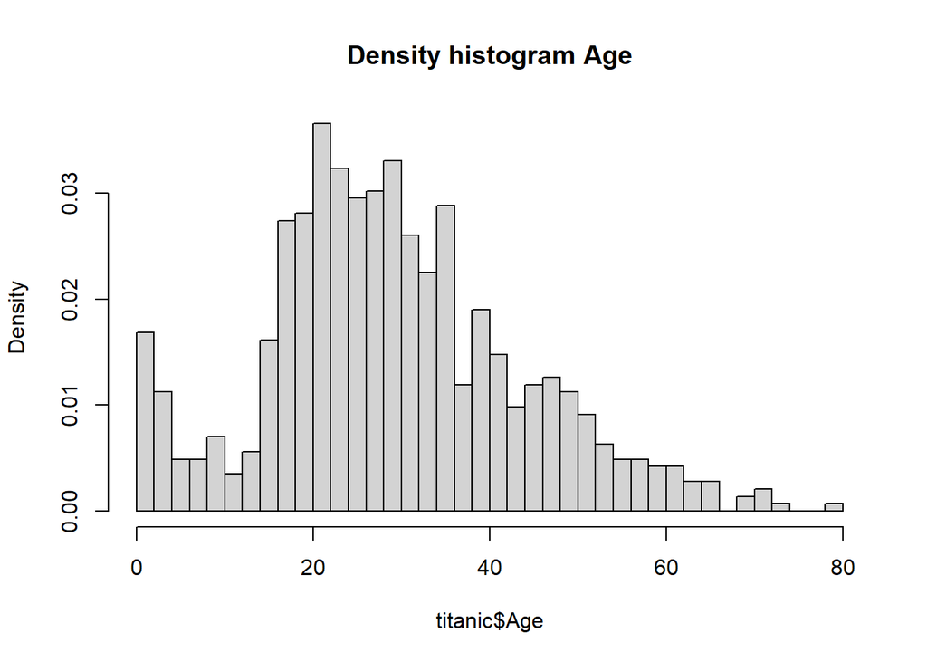

[output not shown]

```r
(hist(titanic$Age, main='Density histogram Age', ylab='Density', breaks=30, freq=FALSE))
```

```r
ind.Age <- which(is.na(titanic$Age))
lineal.model.Age <- lm(Age ~ Survived + Pclass + Sex + Fare, data=titanic)
summary(lineal.model.Age)
```

```
##
## Call:
## lm(formula = Age ~ Survived + Pclass + Sex + Fare, data = titanic)
##
## Residuals:
##     Min      1Q  Median      3Q     Max
## -36.834  -8.453  -0.965   8.006  46.847
##
## Coefficients:
##              Estimate Std. Error t value Pr(>|t|)
## (Intercept)  45.40791    1.92179  23.628  < 2e-16 ***
## SurvivedYes  -6.19600    1.24398  -4.981 7.97e-07 ***
## Pclass2nd   -12.20779    1.58355  -7.709 4.31e-14 ***
## Pclass3rd   -18.93412    1.50806 -12.555  < 2e-16 ***
## Sexmale       1.01624    1.20628   0.842 0.399818
## Fare         -0.04338    0.01161  -3.738 0.000201 ***
## ---
## Signif. codes:  0 '***' 0.001 '**' 0.01 '*' 0.05 '.' 0.1 ' ' 1
##
## Residual standard error: 12.97 on 706 degrees of freedom
##   (177 observations deleted due to missingness)
## Multiple R-squared:  0.2052, Adjusted R-squared:  0.1995
## F-statistic: 36.45 on 5 and 706 DF,  p-value: < 2.2e-16
```

```r
titanic$Age[ind.Age] <- trunc(predict(lineal.model.Age, newdata=titanic[ind.Age,]))
summary(titanic$Age[ind.Age])
```

```
##    Min. 1st Qu.  Median    Mean 3rd Qu.    Max.
##   18.00   25.00   27.00   27.61   27.00   46.00
```

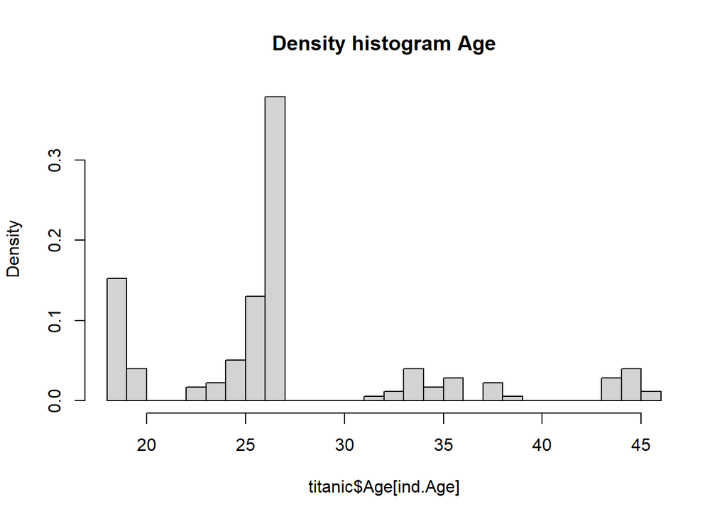

[output not shown]

```r
(hist(titanic$Age[ind.Age], main='Density histogram Age', ylab='Density', breaks=30, freq=FALSE))
```

```r
summary(titanic$Age[-ind.Age])
```

```
##    Min. 1st Qu.  Median    Mean 3rd Qu.    Max.
##    0.42   20.00   28.00   29.64   38.00   80.00
```

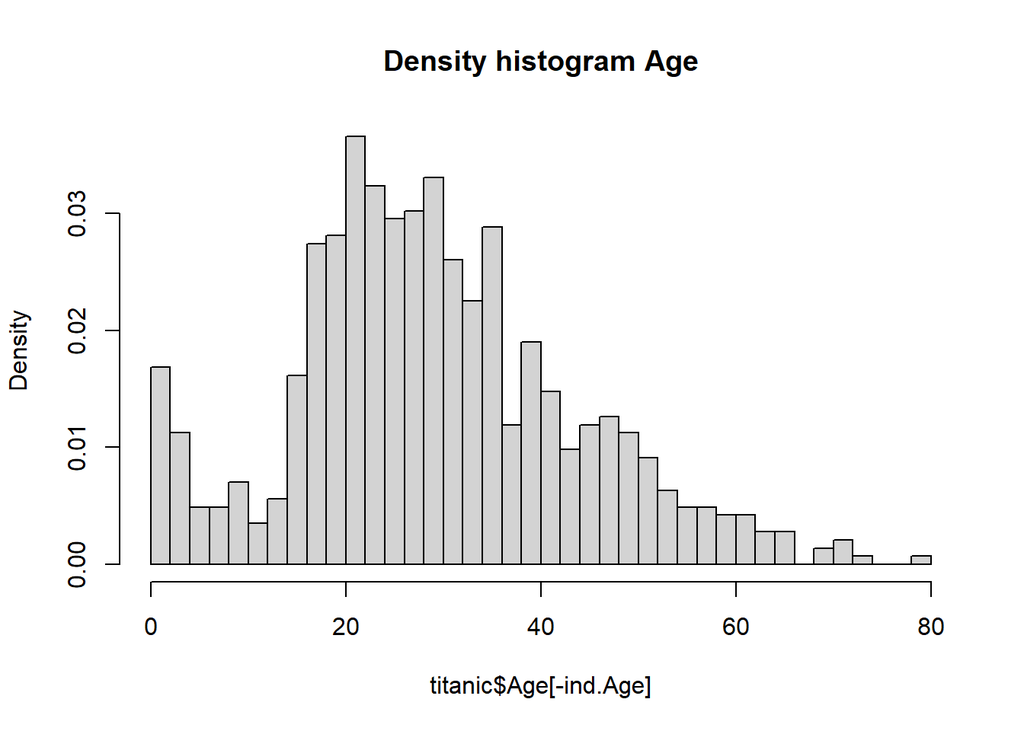

[output not shown]

```r
(hist(titanic$Age[-ind.Age], main='Density histogram Age', ylab='Density', breaks=30, freq=FALSE))
```

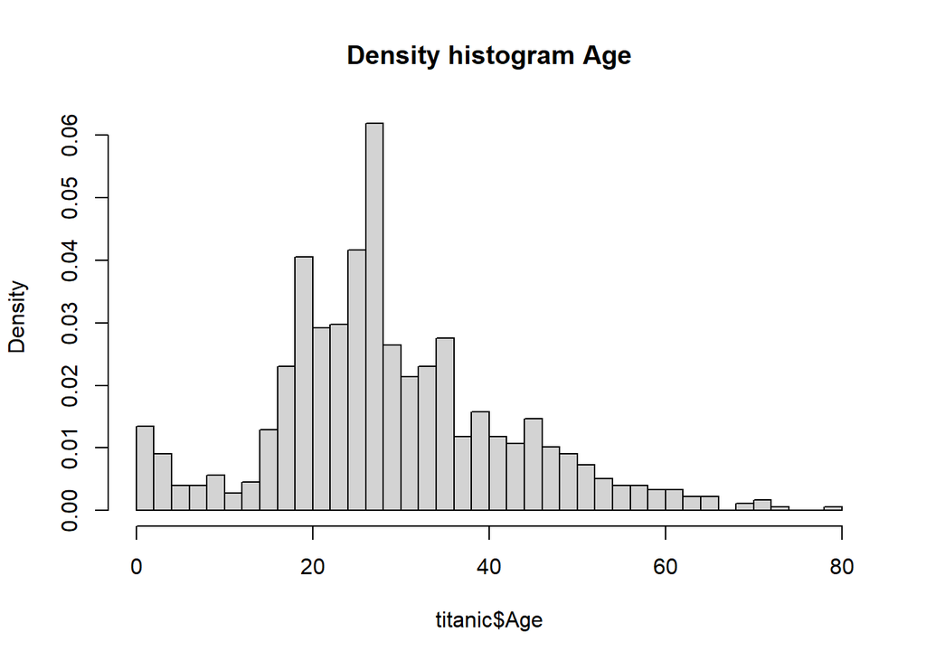

[output not shown]

```r
(hist(titanic$Age, main='Density histogram Age', ylab='Density', breaks=30, freq=FALSE))
```

```r
#ind.Age <- which(is.na(titanic$Age))
#lineal.model.Age <- lm(Age ~ Survived + Pclass + Sex + Fare, data=titanic)
#titanic$Age[ind.Age] <- trunc(predict(lineal.model.Age, newdata=titanic[ind.Age,]))
#summary(titanic$Age[ind.Age])
#summary(titanic$Age[-ind.Age])
```

A priori la imputación de valores parece razonablemente buena ya que tiene valores similares en dos estimadores importantes como son la media y la mediana. También los valores máximo y mínimo de este conjunto están dentro de los de la variable.

Con esto concluimos que esta forma de imputar los valores es mejor que haber colocado a todos los registros el valor de la media o la mediana.

## 3.2 Detección y tratamiento de outliers

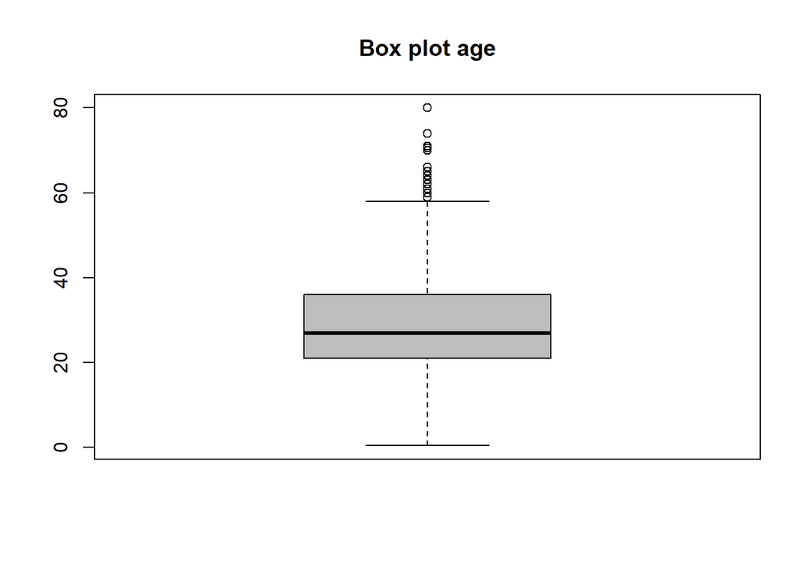

```r
boxplot(titanic$Age,main="Box plot age", col="gray")
```

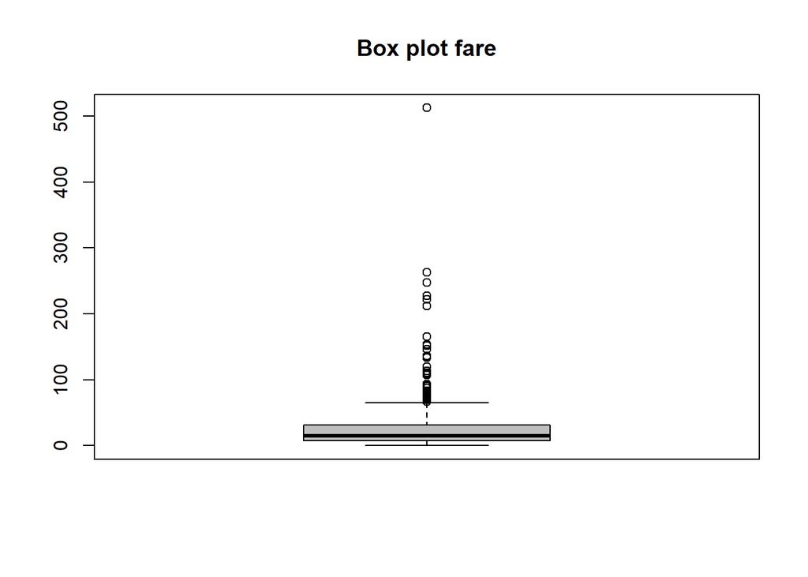

```r
boxplot(titanic$Fare,main="Box plot fare", col="gray")
```

Observamos que en el caso de la edad no vemos ningún outlier que sea relevante ya que los outliers que vemos pertenecen a personas que tienen entre 60 y 80 años que son valores razonables aunque sean notablemente superiores a los del resto del conjunto.

En el caso de la variable Fare vemos muchos outliers lo que puede ser porque las tarifas cambien en función de donde hayan embarcado los pasajeros por lo que vamos a repetir el dibujo de los boxplots pero para cada uno de los conjuntos.

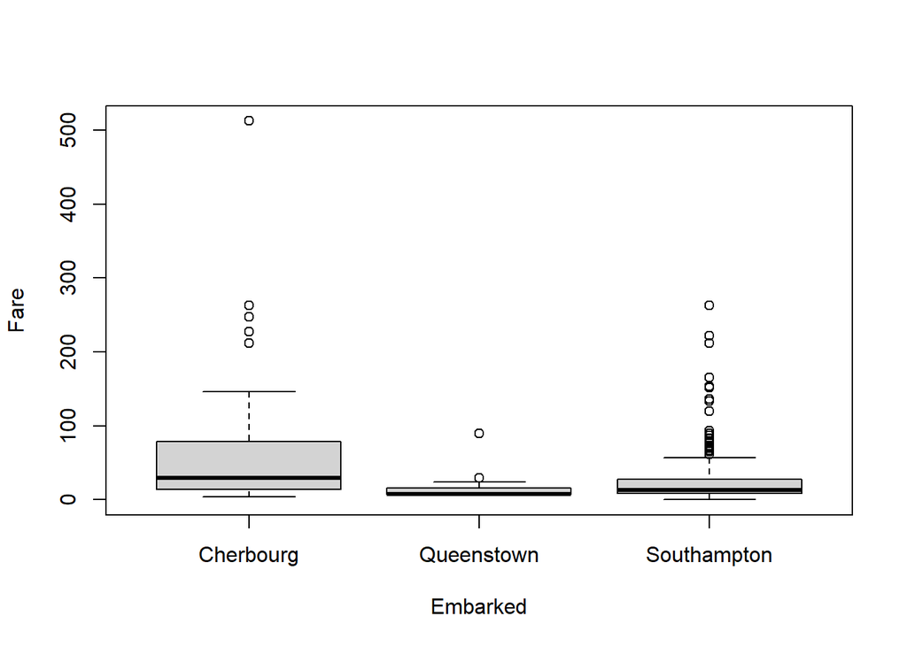

```r
boxplot(Fare ~ Embarked, data = titanic)
```

Observamos un par de outliers destacados en los casos de `Cherbourg` y `Queenstown` que analizaremos a continuación.

```r
max.Cherbourg<- max(boxplot.stats(titanic[titanic$Embarked == 'Cherbourg', 'Fare'])$out)
titanic[titanic$Fare == max.Cherbourg & titanic$Embarked == 'Cherbourg',]
```

```
##     Survived Pclass    Sex Age SibSp Parch     Fare  Embarked
## 259      Yes    1st female  35     0     0 512.3292 Cherbourg
## 680      Yes    1st   male  36     0     1 512.3292 Cherbourg
## 738      Yes    1st   male  35     0     0 512.3292 Cherbourg
```

```r
max.Queenstown<- max(boxplot.stats(titanic[titanic$Embarked == 'Queenstown', 'Fare'])$out)
titanic[titanic$Fare == max.Queenstown & titanic$Embarked == 'Queenstown',]
```

```
##     Survived Pclass    Sex Age SibSp Parch Fare   Embarked
## 246       No    1st   male  44     2     0   90 Queenstown
## 413      Yes    1st female  33     1     0   90 Queenstown
```

No parecen ser outliers ya que pertenecen a billetes de primera clase que son los más caros. Así que no los eliminaremos del conjunto de datos.

# 4 Análisis de datos

## 4.1 Selección de los grupos de datos a analizar

Partiendo de la premisa de que la variable principal de nuestro conjunto de datos es la variable *Survived*, los dos grupos principales que compararemos son supervivientes y no supervivientes a través de las distintas variables.

Lo primero que haremos será generar una serie de histogramas y gráficos de cajas para ver la distribución de la variable *survived* y su relación con el resto de variables.

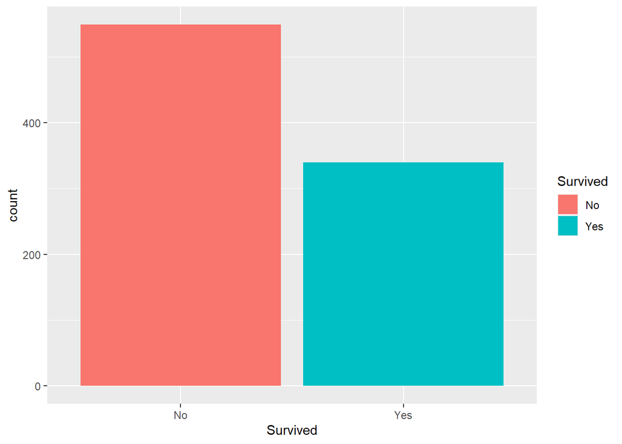

```r
ggplot(data=titanic,aes(x=Survived,fill = Survived))+geom_bar()
```

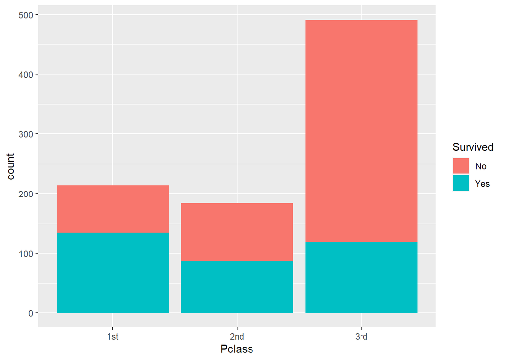

```r
ggplot(data=titanic,aes(x=Pclass,fill=Survived))+geom_bar()
```

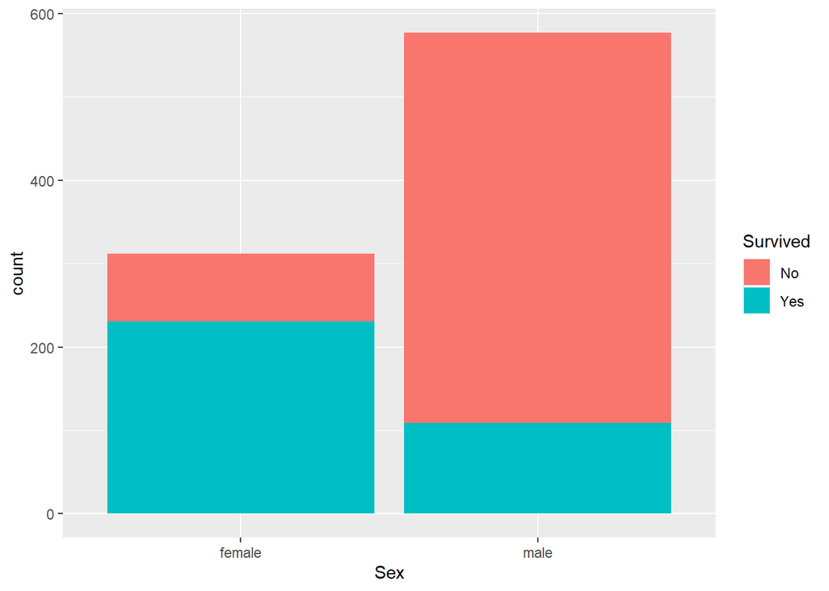

```r
ggplot(data=titanic,aes(x=Sex,fill=Survived))+geom_bar()
```

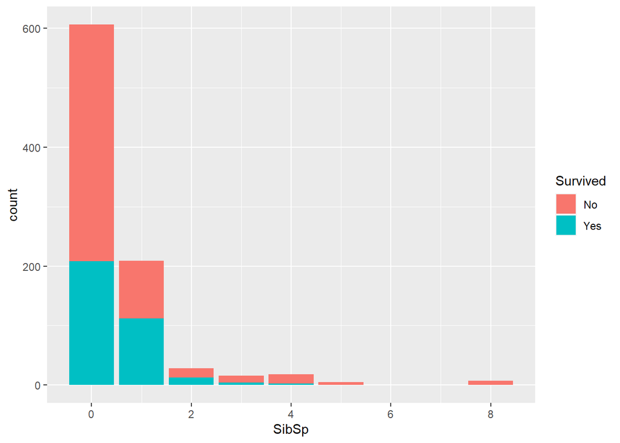

```r
ggplot(data=titanic,aes(x=SibSp,fill=Survived))+geom_bar()
```

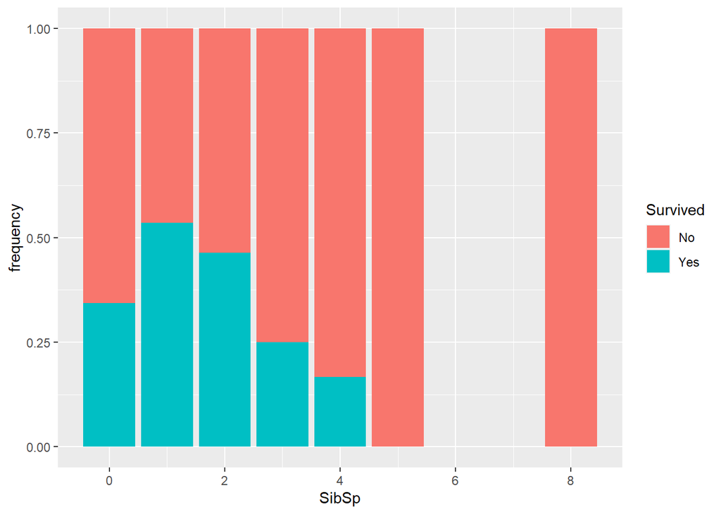

```r
ggplot(data=titanic,aes(x=SibSp,fill=Survived))+geom_bar(position="fill")+ylab("frequency")
```

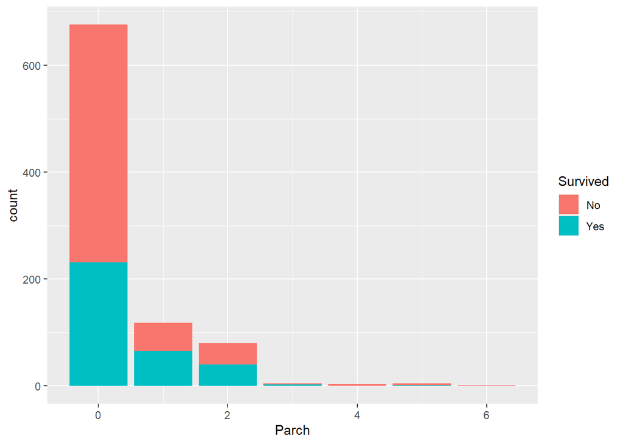

```r
ggplot(data=titanic,aes(x=Parch,fill=Survived))+geom_bar()
```

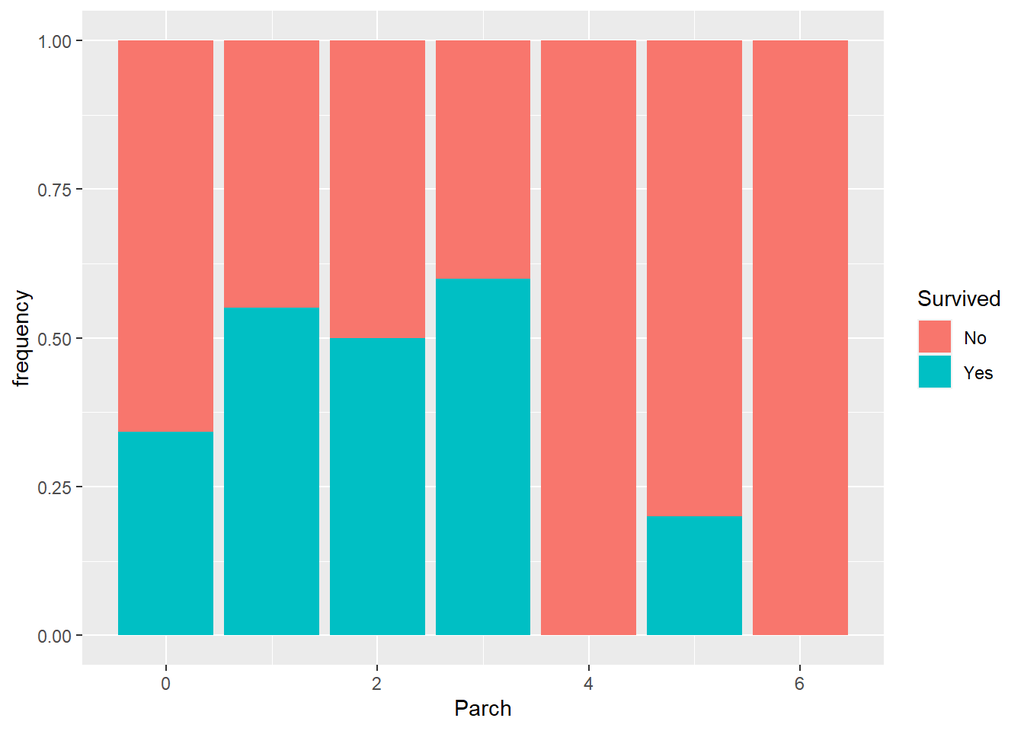

```r
ggplot(data=titanic,aes(x=Parch,fill=Survived))+geom_bar(position="fill")+ylab("frequency")
```

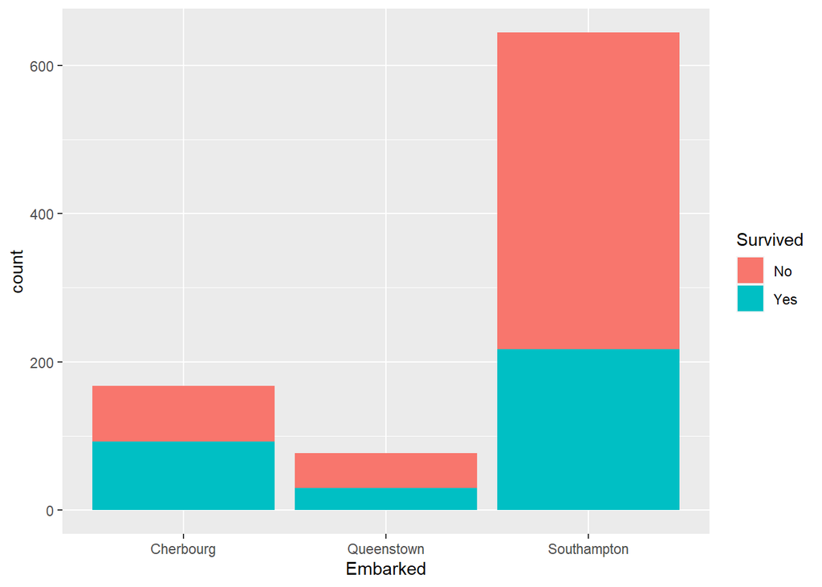

```r
ggplot(data=titanic,aes(x=Embarked,fill=Survived))+geom_bar()
```

Para las variables *SibSp* y *Parch* además de los diagramas de barras, optamos por estandarizar cada barra para que tenga la misma altura y muestre las proporciones relativas ya que el grupo 0 era el más numeroso y no se podría apreciar bien el resto en los gráficos.

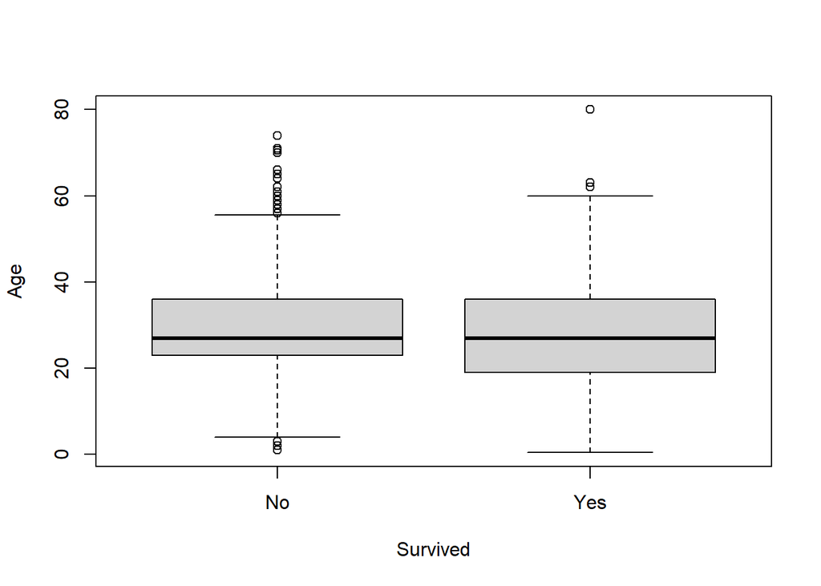

```r
boxplot(Age ~ Survived, data = titanic)
```

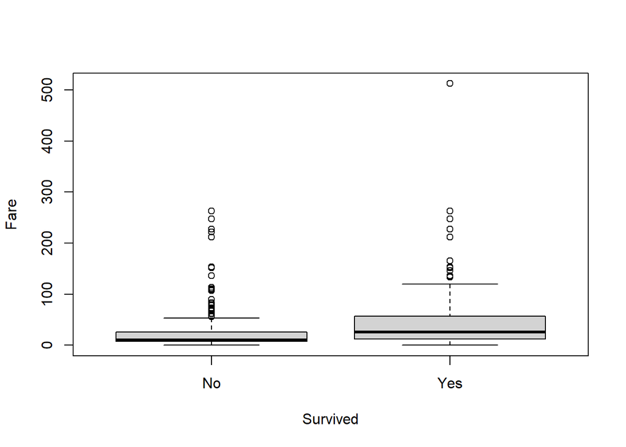

```r
boxplot(Fare ~ Survived, data = titanic)
```

## 4.2 Comprobación de la normalidad y homogeneidad de la varianza

### 4.2.1 Normalidad

El análisis de la normalidad determina si los datos de la muestra se han extraído de una población distribuida normalmente. Dos gráficos con los que es posible comprobar la normalidad son el gráfico Q-Q o cuantil-cuantil y el diagrama de densidad con la curva de distribución normal.

El Q-Q Plot permite identificar la desviación de los datos de la muestra respecto a una población normal. Mediante *qqline* se dibuja una línea recta correspondiente a la distribución normal teórica, y mediante *qqnorm* se dibujan los puntos, que son los datos distribuidos según los cuantiles teóricos. Si los puntos siguen la línea, los datos se distribuyen normalmente.

El diagrama de densidad muestra la distribución de los datos. Se aproximarán a una distribución normal si la densidad es simétrica, centrada en el medio, y disminuye hacia las 2 desviaciones estándar de la media, dentro de las cuales se encuentra aproximadamente el 95% de los datos.

**Variable *Age***

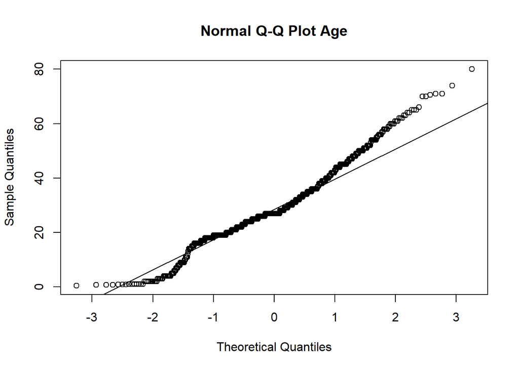

```r
{qqnorm(titanic$Age, main="Normal Q-Q Plot Age")
qqline(titanic$Age)}
```

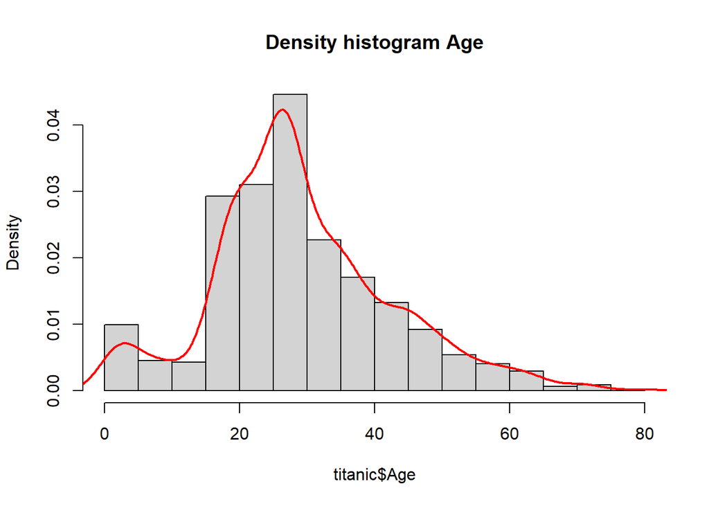

```r
{(hist(titanic$Age, main='Density histogram Age', ylab='Density', freq=FALSE, breaks=20))
lines(density(titanic$Age), col="red", lwd=2)}
```

Test Lilliefors o Shapiro-Wilk.

```r
shapiro.test(titanic$Age)
```

```
##
##  Shapiro-Wilk normality test
##
## data:  titanic$Age
## W = 0.97097, p-value = 2.572e-12
```

```r
if(!require("nortest")) install.packages("nortest")
library("nortest")
lillie.test(titanic$Age)
```

```
##
##  Lilliefors (Kolmogorov-Smirnov) normality test
##
## data:  titanic$Age
## D = 0.10312, p-value < 2.2e-16
```

Para los dos test (o poner solo 1) se verifica la no normalidad al rechazar la hipótesis nula.

**Variable *Fare***

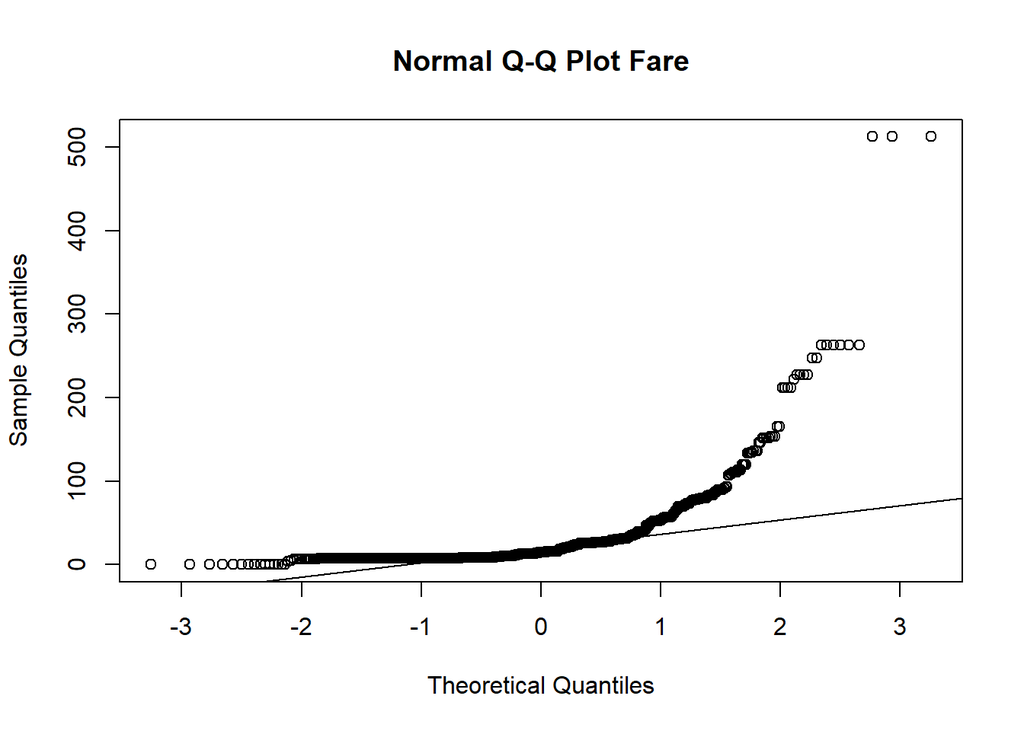

```r
{qqnorm(titanic$Fare, main="Normal Q-Q Plot Fare")
qqline(titanic$Fare)}
```

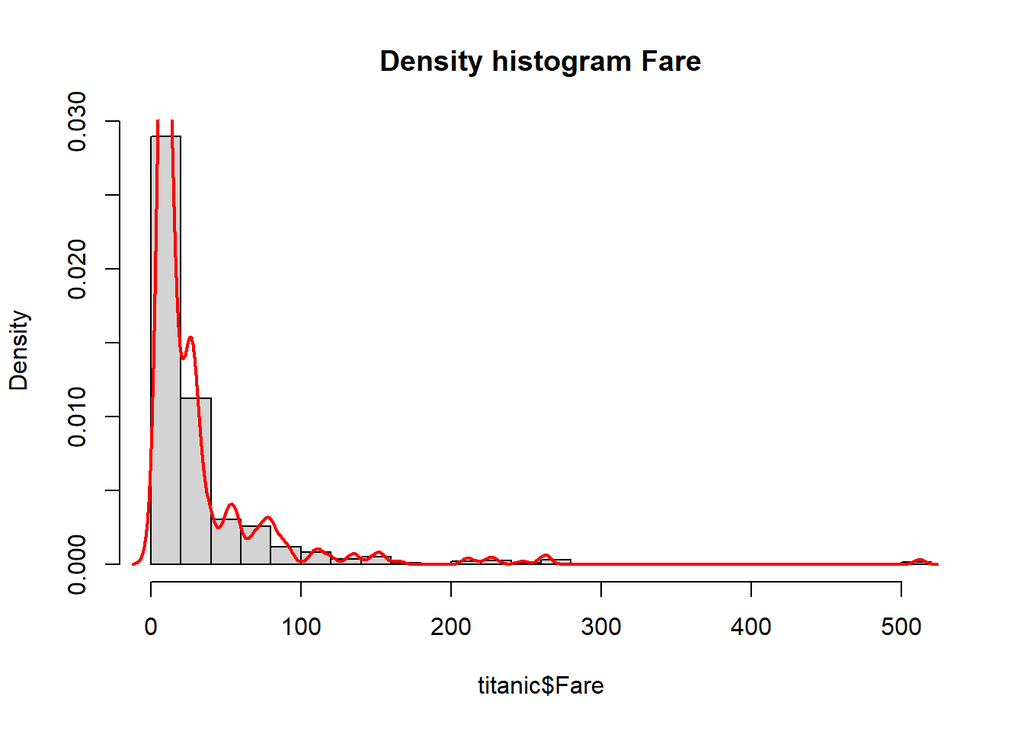

```r
{(hist(titanic$Fare, main='Density histogram Fare', ylab='Density', freq=FALSE, breaks=20))
lines(density(titanic$Fare), col="red", lwd=2)}
```

```r
shapiro.test(titanic$Fare)
```

```
##
##  Shapiro-Wilk normality test
##
## data:  titanic$Fare
## W = 0.5197, p-value < 2.2e-16
```

```r
lillie.test(titanic$Fare)
```

```
##
##  Lilliefors (Kolmogorov-Smirnov) normality test
##
## data:  titanic$Fare
## D = 0.28257, p-value < 2.2e-16
```

### 4.2.2 Homocedasticidad

Según los gráficos y los test de normalidad, como las variables *Age* y *Fare* no siguen una distribución normal, se debería utilizar el test de Fligner-Killen. No obstante, como el TLC dice lo contrario, se debería utilizar el test de Levene basándose en la mediana de los datos, la medida menos sensible a la normalidad.

Por tanto, ¿se aplican los dos test?

**Variable *Age***

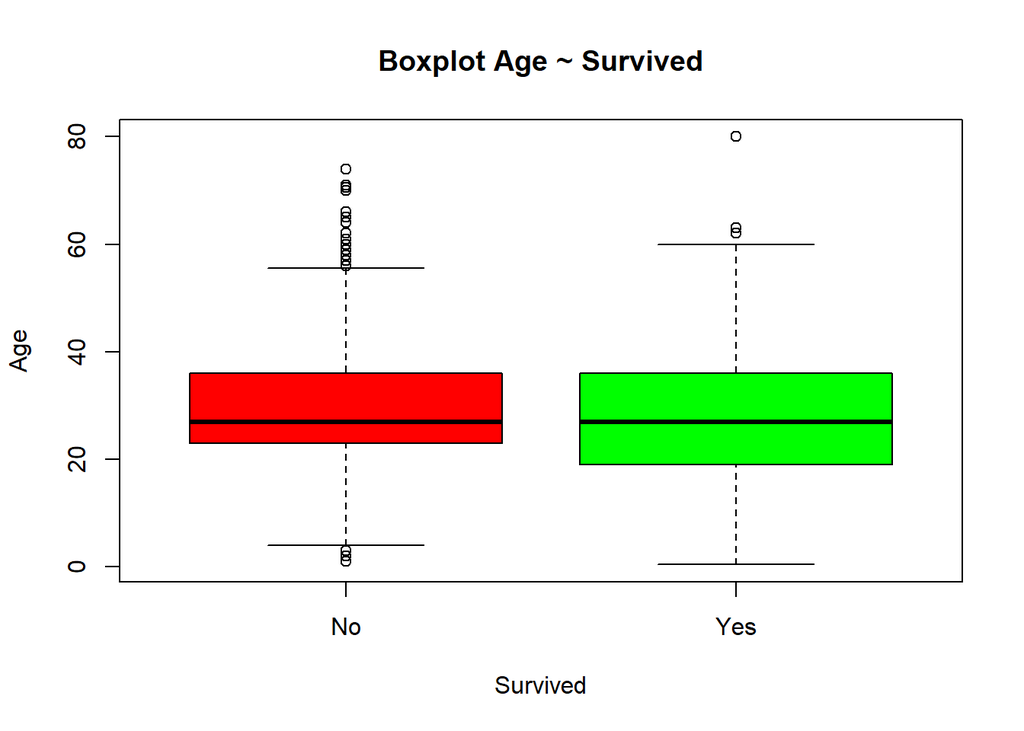

```r
boxplot(Age ~ Survived, data = titanic,
        col=c('red', 'green'),
        main='Boxplot Age ~ Survived')
```

La amplitud de la caja y de los bigotes del grupo que sobrevivió es algo mayor a la amplitud del grupo de no sobrevivió. Como los tamaños son diferentes, se podría concluir que la varianza de la distribución de “Yes” es mayor y, por tanto, no se asume igualdad de varianzas. Sin embargo, al ser una variación no tan grande, es necesario comprobar con los tests.

```r
if(!require("car")) install.packages("car")
library("car")
leveneTest(Age ~ Survived, data=titanic)
```

```
## Levene's Test for Homogeneity of Variance (center = median)
##        Df F value   Pr(>F)
## group   1  8.5194 0.003603 **
##       887
## ---
## Signif. codes:  0 '***' 0.001 '**' 0.01 '*' 0.05 '.' 0.1 ' ' 1
```

```r
fligner.test(Age ~ Survived, data=titanic)
```

```
##
##  Fligner-Killeen test of homogeneity of variances
##
## data:  Age by Survived
## Fligner-Killeen:med chi-squared = 11.674, df = 1, p-value = 0.0006338
```

Dado que para ambas pruebas, el p-valor es inferior al nivel de significancia 0.05, se rechaza la hipótesis nula y se concluye que la variable *Age* presenta varianzas estadísticamente diferentes para los dos grupos de *Survived*.

**Variable *Fare***

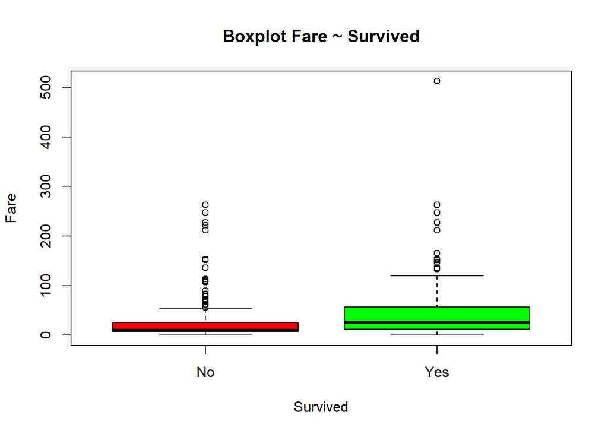

```r
boxplot(Fare ~ Survived, data = titanic,
        col=c('red', 'green'),
        main='Boxplot Fare ~ Survived')
```

La amplitud de la caja y de los bigotes del grupo que sobrevivió es mayor a la amplitud del grupo de no sobrevivió. Esta variación es mucho más clara, ya que la base superior de la caja roja llega a un precio de 25€ y la caja verde a uno de 60€ aproximadamente. Además, el bigote superior del primer grupo solo llega a un precio del 60% y el del segundo a uno de 125€ aproximadamente. Se concluye que las varianzas son diferentes. Para corroborarlo se utilizan los tests.

```r
leveneTest(Fare ~ Survived, data=titanic)
```

```
## Levene's Test for Homogeneity of Variance (center = median)
##        Df F value    Pr(>F)
## group   1  44.372 4.759e-11 ***
##       887
## ---
## Signif. codes:  0 '***' 0.001 '**' 0.01 '*' 0.05 '.' 0.1 ' ' 1
```

```r
fligner.test(Fare ~ Survived, data=titanic)
```

```
##
##  Fligner-Killeen test of homogeneity of variances
##
## data:  Fare by Survived
## Fligner-Killeen:med chi-squared = 94.7, df = 1, p-value < 2.2e-16
```

Para la variable *Fare* lo mismo que *Age*, pero con una conclusión más contundente de heteroscedasticidad (varianzas heterogéneas).

## 4.3 Aplicación de pruebas estadísticas

Todas las pruebas estadísticas tendrán en cuenta la variable objetivo *Survived*. En primer lugar se realizarán dos contrastes de hipótesis, uno con la variable cuantitativa *Fare* y otro con la variable categórica *Sex*. Luego, una regresión logística. Y, finalmente se usará un modelo supervisado de clasificación que predecirá si un pasajero sobrevive o no.

### 4.3.1 Contrastes de hipótesis

El primer paso para un contraste de hipótesis es formular la pregunta de investigación. En base a ella se examinará la hipótesis nula y la alternativa. Finalmente, al usar el test estadístico correcto se aceptará o se rechazará la hipótesis con cierto nivel de confianza.

La primera pregunta que nos hacemos es:

**¿Los pasajeros que sobrevivieron pagaron una entrada más cara que los que fallecieron?**

Se plantea si el precio medio del ticket de los supervivientes ($\mu_1$) es mayor al precio medio del ticket de los fallecidos ($\mu_2$). La hipótesis nula ($H_0$) representa el caso donde no hay efecto, es decir, cuando la media de *Fare* es la misma con un nivel de confianza para todos los pasajeros. La hipótesis alternativa ($H_1$) es cuando se responde afirmativamente a la pregunta, es decir, los los supervivientes pagaron más que los fallecidos.

$$H_0: \mu_1 = \mu_2$$
$$H_1: \mu_1 > \mu_2$$

Se trata de un contraste paramétrico unilateral por la derecha de dos muestras independientes (supervivientes y no supervivientes) sobre la media con varianza desconocida.

Al preguntarse si un grupo pagó más que el otro, el test es unilateral por la derecha.

El test a utilizar es paramétrico ya que, aunque la igualdad de varianzas no se cumple, la distribución de *Fare* se aproxima a una normal. Así que se realiza el test *t-Student*. Y se utilizará un nivel de confianza del 95%.

Se puede aplicar el test manualmente a partir de los grados de libertad y el estadístico de contraste. Si este cae fuera de la región de aceptación y el p-valor es inferior a 0.05, la hipótesis nula se rechaza.

Se crea la función *test_two_samples* que calcula los datos.

```r
test_two_samples <- function(var, var_samples, sample1, sample2, alfa, delta){
  m1 <- var[var_samples==sample1]
  m2 <- var[var_samples==sample2]

  mean1 <- mean(m1)
  n1 <- length(m1)
  s1 <- sd(m1)

  mean2 <- mean(m2)
  n2 <- length(m2)
  s2 <- sd(m2)

  # Grados de libertad
  grados <- ((((s1^2)/n1)+((s2^2)/n2))^2) / ((((s1^2)/n1)^2)/(n1-1) + ((((s2^2)/n2)^2)/(n2-1)))

  # Estadístico de contraste
  tobs <- (mean1-mean2-delta) / (sqrt(((s1^2)/n1)+((s2^2)/n2)))

  # Región de aceptación y p-valor
  tcritL <- "-INF"
  tcritU <- qt(1-alfa, df=grados)
  pvalue <- pt(tobs, lower.tail=FALSE, df=grados)


  cat("Muestra 1:", "\n\tMedia:", mean1, "\n\tDesviación estándar:", s1, "\n\tLongitud:", n1, "\nMuestra 2:", "\n\tMedia:", mean2, "\n\tDesviación estándar:", s2, "\n\tLongitud:", n2, "\n\nGrados de libertad:", grados ,"\ntobs:", tobs, "\nValores críticos:",
      "\n\ttcritL:", tcritL,"\n\ttcritU:", tcritU, "\nvalor p:", pvalue)
}
```

```r
test_two_samples(titanic$Fare, titanic$Survived, "Yes", "No", 0.05, 0)
```

```
## Muestra 1:
##  Media: 48.2095
##  Desviación estándar: 66.74877
##  Longitud: 340
## Muestra 2:
##  Media: 22.11789
##  Desviación estándar: 31.38821
##  Longitud: 549
##
## Grados de libertad: 433.1823
## tobs: 6.759692
## Valores críticos:
##  tcritL: -INF
##  tcritU: 1.648379
## valor p: 2.24133e-11
```

El valor observado $f_{obs} = 6.76$ está fuera de la zona de aceptación de la hipótesis nula [-INF, 1.648]. Además, el p-valor = 2.24e-11 < 0.05.

También se puede aplicar mediante la función *t.test()* que R implementa.

```r
t.test(titanic$Fare[titanic$Survived=="Yes"], titanic$Fare[titanic$Survived=="No"], alternative="greater", var.equal=FALSE)
```

```
##
##  Welch Two Sample t-test
##
## data:  titanic$Fare[titanic$Survived == "Yes"] and titanic$Fare[titanic$Survived == "No"]
## t = 6.7597, df = 433.18, p-value = 2.241e-11
## alternative hypothesis: true difference in means is greater than 0
## 95 percent confidence interval:
##  19.72906      Inf
## sample estimates:
## mean of x mean of y
##  48.20950  22.11789
```

Con el test se comprueba que el contraste de hipótesis, los grados de libertad, el p-valor y las dos medias son las mismas. Se rechaza la hipótesis nula y se concluye que los pasajeros que sobrevivieron pagaron una entrada más cara que los pasajeros que fallecieron con un nivel de confianza del 95%.

La segundapregunta que nos hacemos es:

**¿Existe una relación entre el sexo del pasajero y si sobrevivieron o no?**

La hipótesis nula esque ambas variables son independientes. La hipótesis alternativa es que sí existe una relación y las diferencias son significativas.

```r
table_survived_sex <- table(titanic$Survived, titanic$Sex)

chisq.test(table_survived_sex)
```

```
##
##  Pearson's Chi-squared test with Yates' continuity correction
##
## data:  table_survived_sex
## X-squared = 258.43, df = 1, p-value < 2.2e-16
```

El p-valor es muy bajo -> Sí existen una relación de dependencia entre las dos variables, con un nivel de confianza del 95%.

### 4.3.2 Regresión logística

Primero se separa en training y test.

```r
##library(caret)
##library(caTools)

# Tamaño
smp_size <- floor(0.80 * nrow(titanic))

# Semilla para que los datos sean reproducibles
set.seed(666)

# Separación en el conjunto de entrenamiento y test
separacion <- sample(seq_len(nrow(titanic)), size=smp_size)

train <- titanic[separacion,]
test <- titanic[-separacion,]

c(nrow(train), nrow(test))
```

```
## [1] 711 178
```

```r
table(train$Survived)
```

```
##
##  No Yes
## 446 265
```

```r
table(test$Survived)
```

```
##
##  No Yes
## 103  75
```

Modelo de regresión logística.

```r
model <- glm(formula = Survived ~ Sex + Pclass + Age + SibSp, family = "binomial", data=train)

summary(model)
```

```
##
## Call:
## glm(formula = Survived ~ Sex + Pclass + Age + SibSp, family = "binomial",
##     data = train)
##
## Deviance Residuals:
##     Min       1Q   Median       3Q      Max
## -2.8838  -0.6280  -0.3836   0.6134   2.5632
##
## Coefficients:
##              Estimate Std. Error z value Pr(>|z|)
## (Intercept)  4.626218   0.490869   9.425  < 2e-16 ***
## Sexmale     -2.609684   0.217398 -12.004  < 2e-16 ***
## Pclass2nd   -1.347679   0.304653  -4.424 9.70e-06 ***
## Pclass3rd   -2.790365   0.303805  -9.185  < 2e-16 ***
## Age         -0.056206   0.009388  -5.987 2.14e-09 ***
## SibSp       -0.371420   0.120337  -3.087  0.00203 **
## ---
## Signif. codes:  0 '***' 0.001 '**' 0.01 '*' 0.05 '.' 0.1 ' ' 1
##
## (Dispersion parameter for binomial family taken to be 1)
##
##     Null deviance: 939.07  on 710  degrees of freedom
## Residual deviance: 618.70  on 705  degrees of freedom
## AIC: 630.7
##
## Number of Fisher Scoring iterations: 5
```

Creo que el mejor AIC es poniendo como variables independientes *Sex*, *Pclass*, *Age* y *SibSp*. Al introducir las otras variables, o el AIC aumenta, o la significancia de las variables es baja ya que el p-valor supera el 0.05.

```r
if(!require("caret")) install.packages("caret")
library("caret")

prediction <- predict(model, newdata = test, type="response")

binary_prediction <- ifelse(prediction < 0.5, "No", "Yes")
binary_prediction <- factor(binary_prediction)

confusionMatrix(data = binary_prediction, reference = test$Survived, positive = "No")
```

```
## Confusion Matrix and Statistics
##
##           Reference
## Prediction No Yes
##        No  91  17
##        Yes 12  58
##
##                Accuracy : 0.8371
##                  95% CI : (0.7745, 0.8881)
##     No Information Rate : 0.5787
##     P-Value [Acc > NIR] : 1.3e-13
##
##                   Kappa : 0.6628
##
##  Mcnemar's Test P-Value : 0.4576
##
##             Sensitivity : 0.8835
##             Specificity : 0.7733
##          Pos Pred Value : 0.8426
##          Neg Pred Value : 0.8286
##              Prevalence : 0.5787
##          Detection Rate : 0.5112
##    Detection Prevalence : 0.6067
##       Balanced Accuracy : 0.8284
##
##        'Positive' Class : No
##
```

Las métricas obtenidas de la matriz de confusión son buenas, sobretodo la sensibilidad = 88.35% que corresponde a los pasajeros que el modelo ha clasificado como que no sobrevivieron respecto al total de pasajeros que no sobrevivieron.

```r
if(!require("pROC")) install.packages("pROC")
```

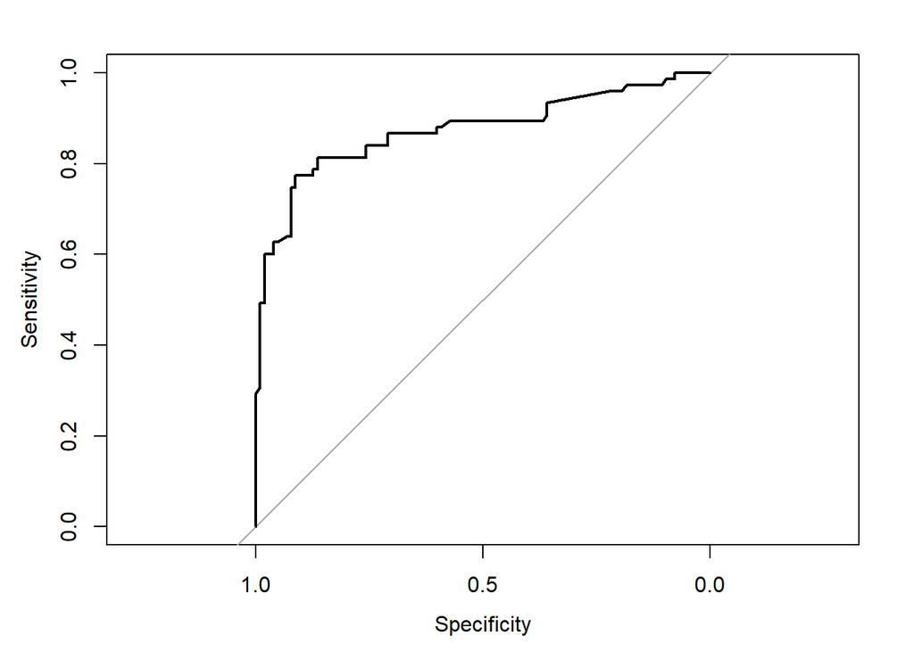

```r
library("pROC")

prob=predict(model, test, type="response")
roc_curve=roc(test$Survived, prob, data=test)
plot(roc_curve)
```

```r
auc(roc_curve)
```

```
## Area under the curve: 0.8737
```

El modelo tiene gran capacidad de clasificar correctamente si sobrevive o no, dado el género, la clase del billete, la edad y el número de hermanos y parejas también en el barco.

### 4.3.3 Random Forest

Un Random Forest es un conjunto o *ensamble* de árboles de decisión combinados con *bagging*. Es decir, en cada árbol se utiliza una porción de los datos de entrenamiento y ningún árbol mira exactamente los mismos datos que otro árbol, compensando los errores de cada uno. Esta capacidad de entrenarse permite al modelo generalizar mejor y evitar el sobreajuste.

Random Forest es implementa mediante la función *randomForest* del paquete con el mismo nombre.

```r
if(!require("randomForest")) install.packages("randomForest")
library("randomForest")

# Separación en train y test
set.seed(666)
split <- floor(nrow(titanic)*0.75)

train2 <- titanic[1:split,]
test2 <- titanic[(split+1):nrow(titanic),]

train2 <- train2[,c(1:4,7)]
test2x <- test2[,c(2:4,7)]
test2y <- test2[,1]

# Modelo
model2 <- randomForest(Survived~., data=train2, ntree=1500)
model2
```

```
##
## Call:
##  randomForest(formula = Survived ~ ., data = train2, ntree = 1500)
##                Type of random forest: classification
##                      Number of trees: 1500
## No. of variables tried at each split: 2
##
##         OOB estimate of  error rate: 16.37%
## Confusion matrix:
##      No Yes class.error
## No  377  30  0.07371007
## Yes  79 180  0.30501931
```

La tasa del error al crear el modelo es del 16.37%, concretamente del 7.37% para los no supervivientes y del 30.50 para los supervivientes.

Al hacer el plot del modelo se obtiene una gráfica el error para la clase 1 (rojo), la clase 2 (verde) y las muestras a usar (negro) sobre la cantidad de los 1500 árboles creados gracias al parámetro *ntree*.

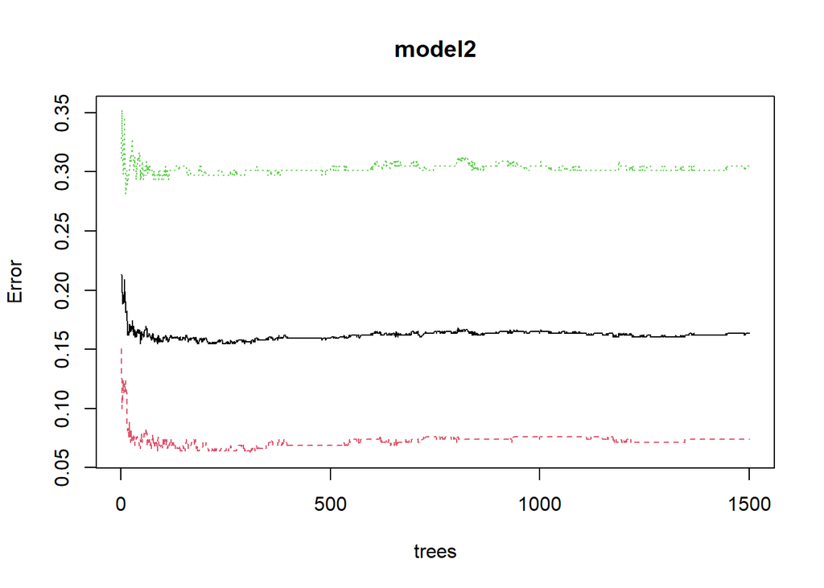

```r
plot(model2)
```

Número de nodos usados en cada árbol:

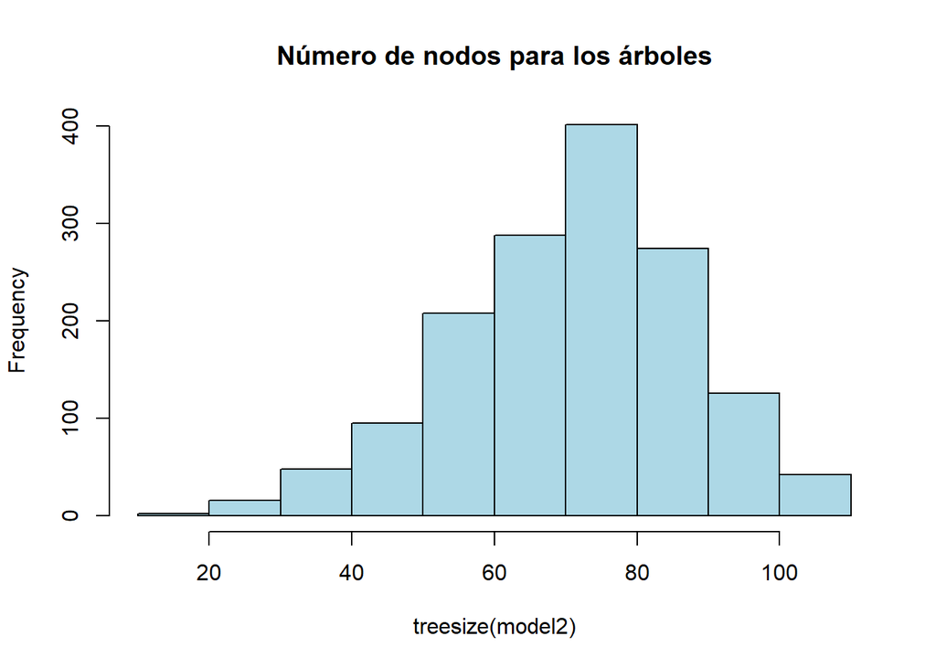

```r
hist(treesize(model2),
     main = "Número de nodos para los árboles",
     col = "lightblue")
```

Importancia de las variables en el modelo:

```r
importance(model2)
```

```
##        MeanDecreaseGini
## Pclass         28.48923
## Sex            84.65778
## Age            65.49510
## Fare           64.01224
```

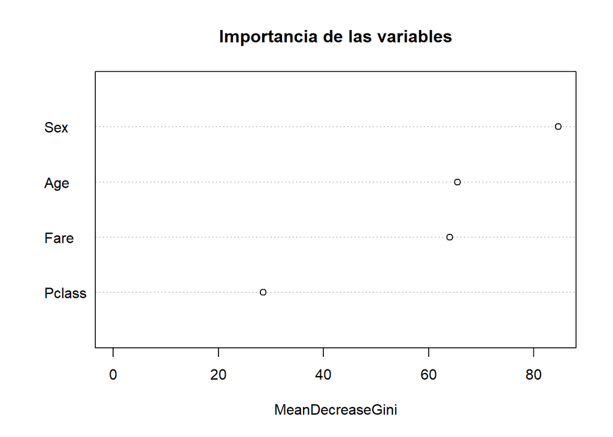

```r
varImpPlot(model2,
           n.var = 4,
           main = "Importancia de las variables")
```

Se había probado un modelo inicial con todas las variables pero se descartaron aquellas con una importancia inferior a 20.

```r
predicted_model2 <- predict(model2, test2)
confusionMatrix(data=predicted_model2, reference=test2$Survived, positive='No')
```

```
## Confusion Matrix and Statistics
##
##           Reference
## Prediction  No Yes
##        No  137  21
##        Yes   5  60
##
##                Accuracy : 0.8834
##                  95% CI : (0.8338, 0.9224)
##     No Information Rate : 0.6368
##     P-Value [Acc > NIR] : < 2.2e-16
##
##                   Kappa : 0.7368
##
##  Mcnemar's Test P-Value : 0.003264
##
##             Sensitivity : 0.9648
##             Specificity : 0.7407
##          Pos Pred Value : 0.8671
##          Neg Pred Value : 0.9231
##              Prevalence : 0.6368
##          Detection Rate : 0.6143
##    Detection Prevalence : 0.7085
##       Balanced Accuracy : 0.8528
##
##        'Positive' Class : No
##
```

# 5 Resolución del problema